# Analysis of twitter users activity on WeRateDogs

```python
from IPython.display import Image
```

To make the distribution plot to near normal it is transformed into log.

It can be observed that very few tweets have retweet and majority of them fall into right tail distribution.

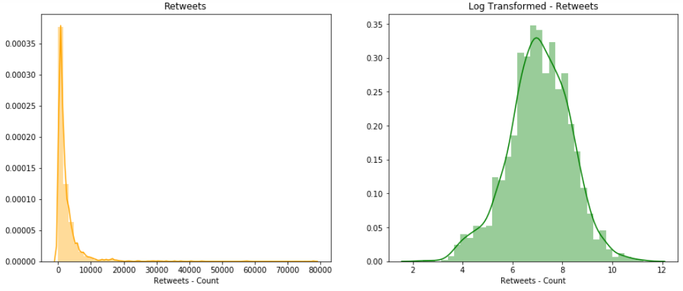

```python
Image(filename='retweets.PNG')
```

It can be observed that very few tweets have favorites and majority of them fall into right tail distribution.

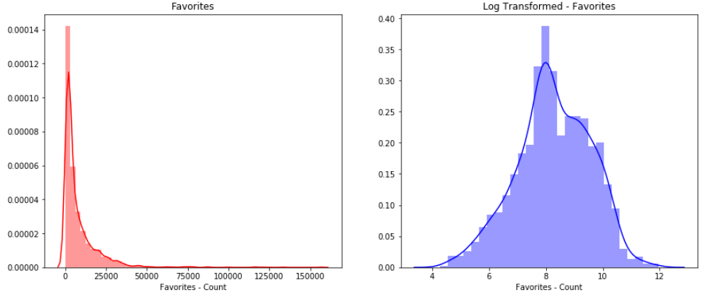

```python
Image(filename='fav.PNG')
```

Testing correlation with numeric attributes ->

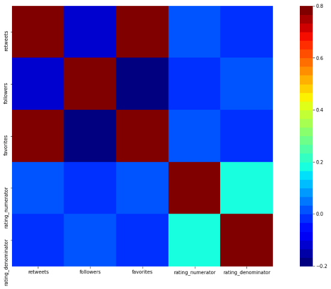

```python
Image(filename='corr.PNG')
```

It can be seen that retweets and favourites have high correlation. This means that people who retweeted also added the favorite tag.

Further clarification can be gained by plotting a scatterplot

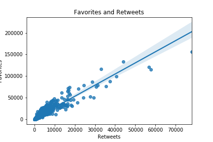

```python
Image(filename='fav_retweet_scatter.png')
```

This shows that they both follow the same trend. It can be interpreted that most of the people add a favourite because it acts as a bookmark.

Retweets are not saved in the twitter profile. The analysis helped me learn and gain good awareness about the website.

Ouput produced from different image prediction algorithms ->

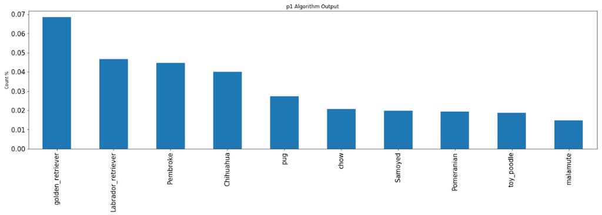

```python
Image(filename='p1.PNG')
```

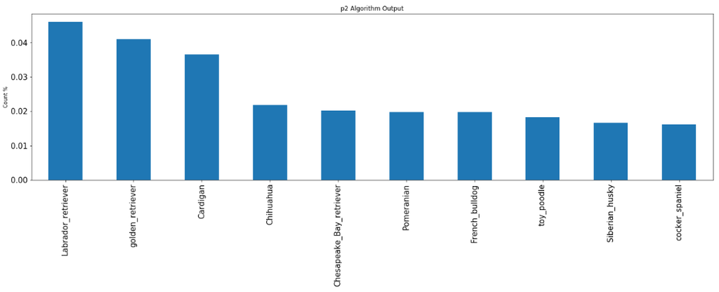

```python
Image(filename='p2.PNG')
```

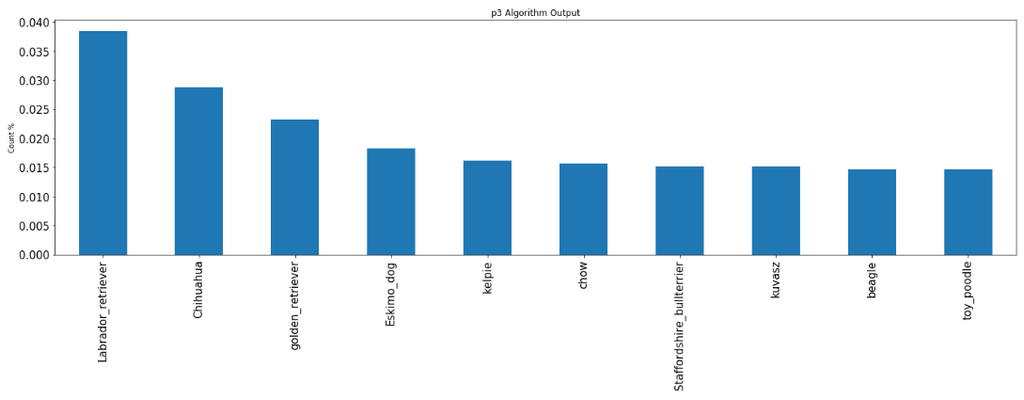

```python
Image(filename='p3.PNG')
```

From the graph it can be seen that, most of the predictions are done for golden_retriever, Labrador_retriever and Chihuahua dogs.

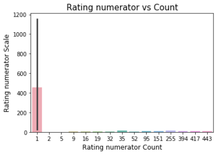

```python
Image(filename='rating_num.PNG')
```

Majority of the ratings are around 10

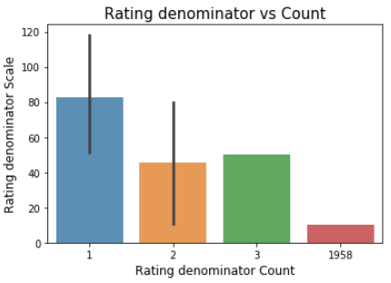

```python
Image(filename='rating_dem.PNG')
```

- There must be rating denominator with 10, but sometimes users are rated with < 10 and > 10.
- So, 1958 are rated on 10.